# Youtube-Icerik-Analizi

Zehra İrem ÇAKMAK

2024-05-13

## 1. Kullanılan Kütüphaneler

```r
library(textdata) # Metin madenciliği (text mining) uygulamaları için veri setleri sağlar.
library(tuber) # YouTube Data API'ye erişim sağlar, YouTube verilerini çekmek ve analiz etmek için kullanılır.
library(httpuv) # Web uygulamaları ve sunucu tarafı programlama için kullanılan bir HTTP ve WebSocket kütüphanesi. Shiny uygulamaları gibi etkileşimli web uygulamaları için gereklidir.
library(httr) # HTTP istekleri göndermek ve almak için kullanılır. API'larla etkileşim kurmak için faydalıdır.
library(tidytext) # Metin madenciliği ve veri çerçeveleri arasında geçiş yapmak için kullanılır, metin verilerini analiz etmeye yardımcı olur.
library(dplyr) # Veri çerçeveleri üzerinde veri manipülasyonu için kullanılır, veriyi filtrelemek, düzenlemek ve özetlemek için işlevler sağlar.
library(ggplot2) # Görselleştirme ve grafik oluşturma için kullanılır, estetik ve özelleştirilebilir grafikler yapmayı sağlar.
library(stopwords) # Dil bağımsız bir şekilde sık kullanılan kelimelerin listesini içerir, metin madenciliğinde anlamsız kelimeleri çıkarmak için kullanılır.
library(tm) # Metin madenciliği için kullanılır, metin verilerini işlemek ve analiz etmek için araçlar sağlar.
library(stringr) # Metin dizileri üzerinde işlemler gerçekleştirmek için kullanılır, dize manipülasyonu için fonksiyonlar içerir.
library(quanteda) # Metin madenciliği ve metin analizi uygulamaları için kullanılan bir paket, büyük metin koleksiyonlarını analiz etmek için kullanılır.
library(wordcloud2) # Kelime bulutları oluşturmak için kullanılır, görsel olarak kelime frekanslarını gösterir.
library(RColorBrewer) # Grafiklerde renk paletleri oluşturmak için kullanılır, ggplot2 ile renk paletlerini entegre eder.
library(htmltools) # HTML belgelerini oluşturmak ve düzenlemek için kullanılır, Shiny uygulamaları ve R Markdown belgeleri ile birlikte kullanılır.
library(qdap) # Metin madenciliği ve analiz için çeşitli araçlar içerir, metin verilerini temizlemek ve analiz etmek için fonksiyonlar sunar.
library(corpustools) # Metin madenciliği uygulamaları için kullanılır, büyük metin koleksiyonlarını analiz etmek için araçlar sağlar.
library(slam) # Büyük ve seyrek matrisler üzerinde çalışmak için kullanılır, sparse matris işlemlerini kolaylaştırır.
library(tokenizers) # Metin madenciliği uygulamaları için belirli dilimleme görevlerini gerçekleştirmek için kullanılır, metin verilerini parçalara ayırır.
library(pander) # R Markdown ve R script dosyalarını zenginleştirmek için kullanılır, sonuçları biçimlendirmek ve sunmak için fonksiyonlar içerir.
library(DT) # Veri çerçevelerini interaktif olarak göstermek için kullanılır, dinamik ve etkileşimli tablolar oluşturur.
library(openxlsx) # Excel dosyalarını okumak ve yazmak için kullanılır, Excel dosyalarıyla çalışmayı kolaylaştırır.
library(writexl) # Excel dosyalarını yazmak için kullanılır, basit ve hızlı bir şekilde Excel dosyaları oluşturur.
library(sentimentr) # Duygu analizi yapmak için kullanılır, metin verilerindeki duygusal tonları analiz eder.
library(pastecs) # Temel istatistik analizlerini gerçekleştirmek için kullanılır, tanımlayıcı istatistikler sağlar.
library(ggthemes) # ggplot2 grafikleri için özel temalar oluşturmak için kullanılır, grafiklerin stilini özelleştirmeyi sağlar.
library(ggpubr) # ggplot2 ile yayın kalitesinde grafikler oluşturmak için kullanılır, grafikleri birleştirme ve düzenleme fonksiyonları içerir.
library(formattable) # Tabloları özelleştirmek ve biçimlendirmek için kullanılır, sonuçların görsel olarak sunumunu iyileştirir.
library(ggstance) # ggplot2 grafiklerini yatay düzlemde oluşturmak için kullanılır, yatay grafikler çizmeyi sağlar.
library(GGally) # ggplot2 grafiklerini daha hızlı oluşturmak için kullanılır, grafik kombinasyonları ve matris grafikleri oluşturur.
library(report) # R Markdown belgelerini oluşturmak ve yönetmek için kullanılır, analiz sonuçlarını raporlama fonksiyonları içerir.
library(citation) # R paketleri için atıf bilgilerini otomatik olarak oluşturmak ve yönetmek için kullanılır, atıf formatlarını sağlar.
library(hwordcloud) # Metin madenciliği uygulamalarında kullanılan bir kelime bulutu oluşturma paketi, kelime frekanslarını görselleştirir.
library(syuzhet) # Metinlerin içerdiği duygusal özellikleri analiz etmek için kullanılır, duygu analizi için çeşitli yöntemler sağlar.
library(emojifont) # Grafiklerde emoji ve simgeler kullanmak için gerekli fontları sağlar, ggplot2 ile entegre olur.
library(showtext) # Grafiklerde özel fontlar kullanmak için gerekli araçları sağlar, ggplot2 ve diğer grafik araçlarıyla çalışır.
library(gridExtra) # Birden fazla grafik veya tabloyu tek bir grafikte birleştirmek için kullanılır, grid yapısını kullanarak düzenler.
library(readxl) # Excel dosyalarını okumak için kullanılır, çeşitli Excel dosyası formatlarını destekler.
library(knitr) # R Markdown belgelerini oluşturmak ve derlemek için kullanılır, dinamik raporlama sağlar.
library(kableExtra) # Tabloları biçimlendirmek ve zenginleştirmek için kullanılır, knitr ile birlikte kullanılır.
library(ggimage) # ggplot2 grafiklerine görüntü eklemek için kullanılır, görselleri entegre eder.
library(tidyr) # Verileri yeniden şekillendirmek ve düzenlemek için kullanılır, veri temizleme ve manipülasyon araçları sunar.
library(plotly) # Etkileşimli ve dinamik grafikler oluşturmak için kullanılır, ggplot2 ile birlikte çalışabilir ve web tabanlı görselleştirme sağlar.
```

Yukarıda, verilerin çekilmesinde, frekans analizi, duygu analizi ve emoji analizi yapılmasında, yapılan analizlerin görselleştirilmesinde kullanılmış olan kütüphaneler verilmiştir.

## 2. Youtube Veri Çekime

client_id<-“your_client_ıd”

clientsecret<-“your_client_secret”

yt_oauth(client_id,clientsecret,token = ” “)

egitim_videosu <- get_all_comments(video_id = “P6FORpg0KVo”)

write.xlsx(egitim_videosu, “egitim.xlsx”, utf8 = TRUE)

Yukarıdaki kodlarla Youtube üzerinden API bağlantısı sağlanarak eğitim konulu videonun verileri çekilmiş ve veriler excel dosyası olarak kaydedilmiştir. Bu kodlarda “tuber”ve “openxlsx” paketleri kullanılmıştır. Verileri çekilecek her bir video için aynı işlem uygulanmıştır.

## 3.Çekilen Verilerin R’a Aktarılması

Daha önceden çekip excel’e attığımız verileri işlem yapmak için R’a aktarıyoruz.Openxlsx paketini kullanıyoruz.

```r
egitim <- read.xlsx("C:\\Sosyal Medya ve Web Analizi Proje Odevi\\egitim.xlsx")
ask_me_anything <- read.xlsx("C:\\Sosyal Medya ve Web Analizi Proje Odevi\\ask_me_anything.xlsx")
challenge <- read.xlsx("C:\\Sosyal Medya ve Web Analizi Proje Odevi\\challenge.xlsx")
kutu_acma <- read.xlsx("C:\\Sosyal Medya ve Web Analizi Proje Odevi\\kutu_acma.xlsx")
soru_cevap <- read.xlsx("C:\\Sosyal Medya ve Web Analizi Proje Odevi\\soru_cevap.xlsx")
sosyal_deney <- read.xlsx("C:\\Sosyal Medya ve Web Analizi Proje Odevi\\sosyal_deney.xlsx")
makyaj <- read.xlsx("C:\\Sosyal Medya ve Web Analizi Proje Odevi\\makyaj.xlsx")
asmr <- read.xlsx("C:\\Sosyal Medya ve Web Analizi Proje Odevi\\asmr.xlsx")
mukbang <- read.xlsx("C:\\Sosyal Medya ve Web Analizi Proje Odevi\\mukbang.xlsx")
egzersiz <- read.xlsx("C:\\Sosyal Medya ve Web Analizi Proje Odevi\\egzersiz.xlsx")
yemek <- read.xlsx("C:\\Sosyal Medya ve Web Analizi Proje Odevi\\yemek.xlsx")
moda <- read.xlsx("C:\\Sosyal Medya ve Web Analizi Proje Odevi\\moda.xlsx")
komplo_teorisi <- read.xlsx("C:\\Sosyal Medya ve Web Analizi Proje Odevi\\komplo_teorisi.xlsx")
reaction <- read.xlsx("C:\\Sosyal Medya ve Web Analizi Proje Odevi\\reaction.xlsx")
vlog <- read.xlsx("C:\\Sosyal Medya ve Web Analizi Proje Odevi\\vlog.xlsx")
roportaj <- read.xlsx("C:\\Sosyal Medya ve Web Analizi Proje Odevi\\roportaj.xlsx")
oyun <- read.xlsx("C:\\Sosyal Medya ve Web Analizi Proje Odevi\\oyun.xlsx")
```

Çağırdığımız verileri daha sonra kolayca kullanabilmek için bir liste içerisine alıyoruz.

```r
veriler <- list(
  "Egitim Videosu" = egitim,
  "Ask Me Anything Videosu" = ask_me_anything,
  "Challenge Videosu" = challenge,
  "Kutu Acma Videosu" = kutu_acma,
  "Soru-Cevap Videosu" = soru_cevap,
  "Sosyal Deney Videosu" = sosyal_deney,
  "Makyaj Videosu" = makyaj,
  "ASMR Videosu" = asmr,
  "Mukbang Videosu" = mukbang,
  "Egzersiz Videosu" = egzersiz,
  "Yemek Videosu" = yemek,
  "Moda Videosu" = moda,
  "Komplo Teorisi Videosu" = komplo_teorisi,
  "Reaction Videosu" = reaction,
  "Roportaj Videosu" = roportaj,
  "Oyun Videosu" = oyun,
  "Vlog Videosu" = vlog
  )
```

## 4. Verilerin Temizlenmesi

Verilerdeki durak kelimeleri silmek için StopWords dosyamızı çağırıyoruz.

```r
StopWords <- readLines("C:\\Sosyal Medya ve Web Analizi Proje Odevi\\stopwords.csv")

silinecek_kelimeler <- c("spencer","shane","ryland","literally","heard","justin","спасибо","おめでとう","thích","thương","pharrell","mukbang","мистер","приедешь","видео","views","кыргызстан","brian","jihyo","lalisa","chapterwithlalisa","allrounderlisaday","feliz","dreams","nakikita","tucker","carlson","dolphin","callahan","dream","badboyhalo","dolphins","george","president","interview,","russian","philippines","lisaaa","สุขสันต")
```

Verileri temizlemek için bir fonksiyon oluşturuyoruz.dplyr, stringr,tidytext paketlerini kullanıyoruz.

```r
temizle_yorumlar <- function(veriler, stopwords) {
  veriler %>%
    mutate(X = row_number()) %>%
    mutate(emoji = stringi::stri_extract_all_regex(textOriginal, "\\p{So}")) %>%
    select(X, textOriginal, emoji) %>%
    mutate(word = str_to_lower(textOriginal)) %>%
    unnest_tokens(word, textOriginal) %>%
    mutate(word = str_replace_all(word, "[[:punct:]]", "")) %>%
    mutate(word = str_squish(word)) %>%
    mutate(word = str_replace_all(word, "[0-9]", "")) %>%
    filter(!word %in% c(stopwords, silinecek_kelimeler)) %>%
    filter(str_length(word) > 4) %>%
    mutate(word = str_replace_all(word, "ı", "i")) %>%
    as_tibble()
}
```

Oluşturduğumuz fonksiyonla bir döngü yaparak bütün dosyaları temizliyoruz.dplyr, stringr , tidytext

```r
temizlenmis_veriler <- lapply(veriler, temizle_yorumlar, stopwords = StopWords)
names(temizlenmis_veriler) <- names(veriler)
```

## 5.Frekans Analizi

Aşağıdaki kod bloğu ile daha önce temizlediğimiz verilerin frekans analizini yapıyoruz.dplyr, ggplot2 paketlerini kullanıyoruz.

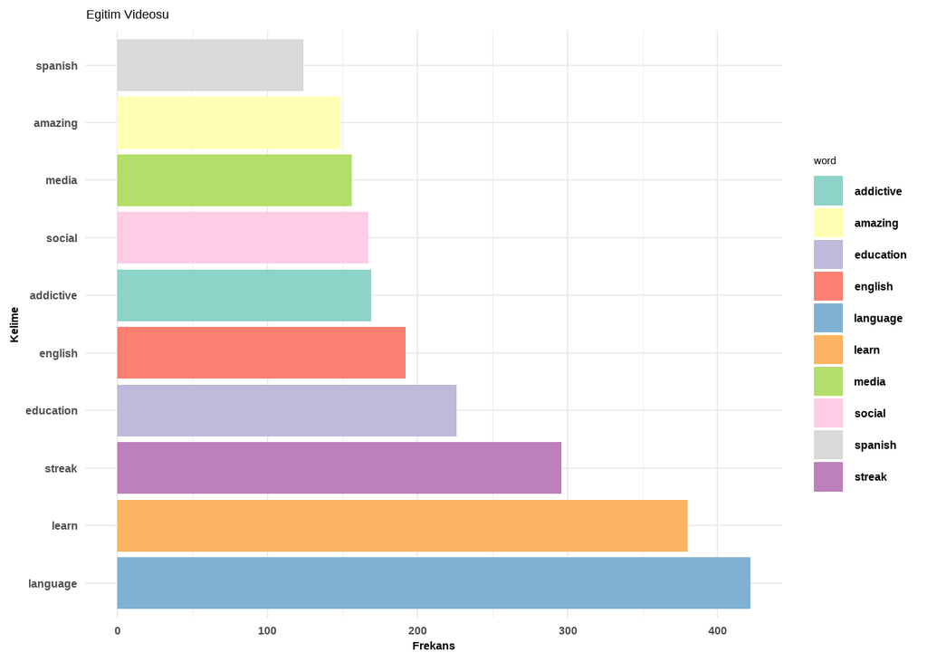

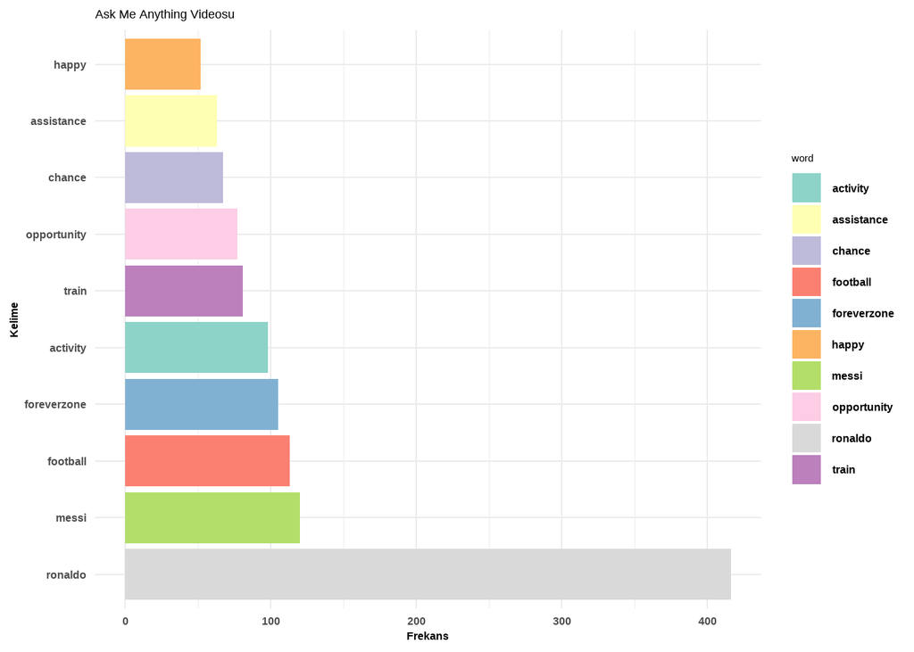

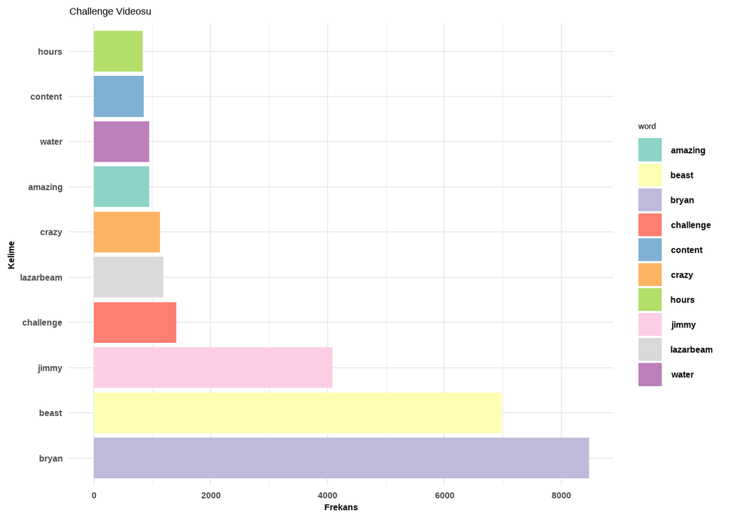

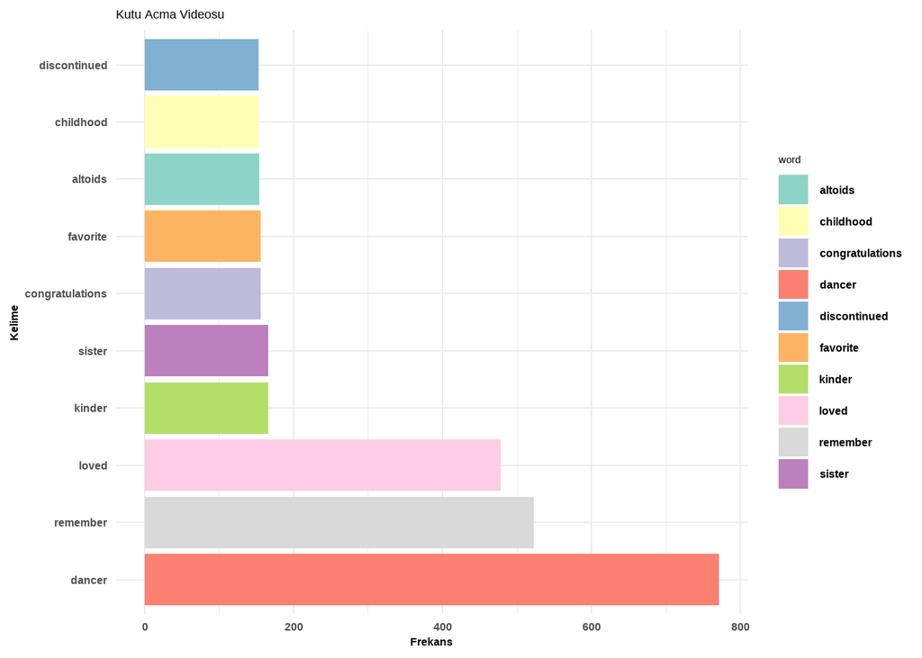

[figure not shown]

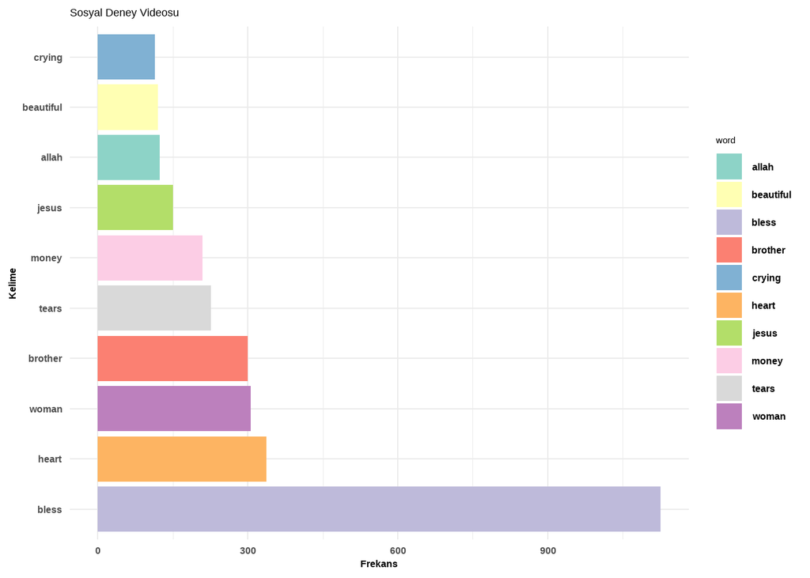

[figure not shown]

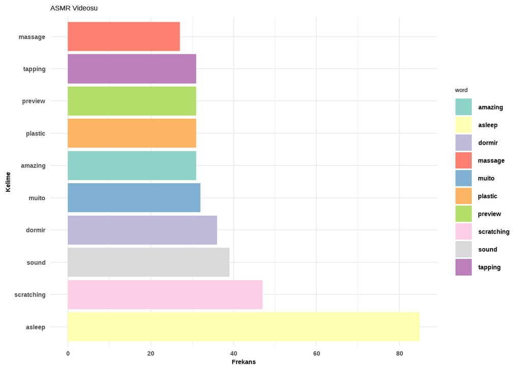

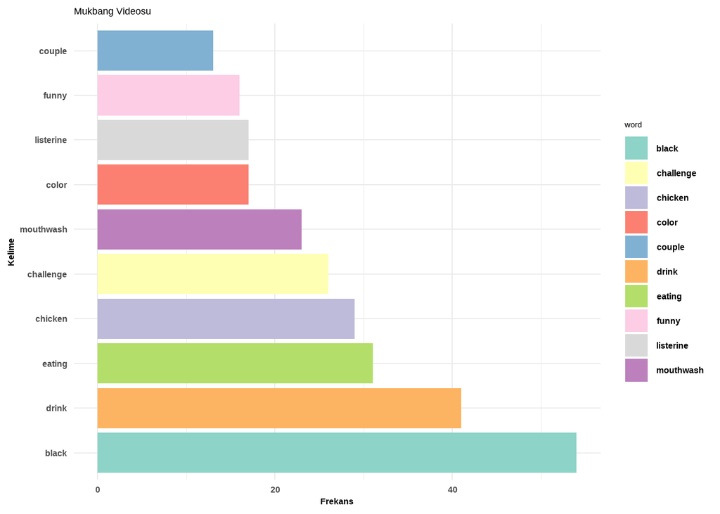

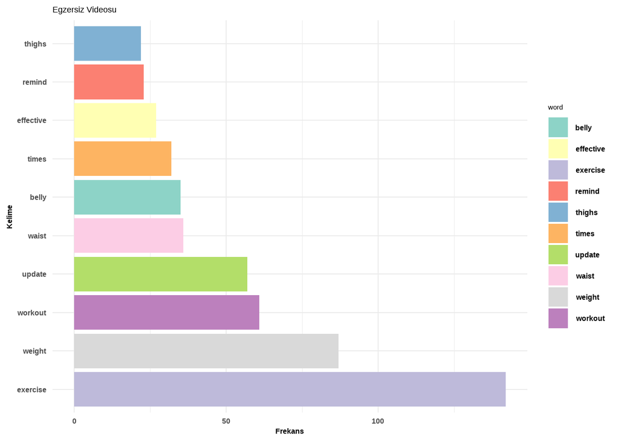

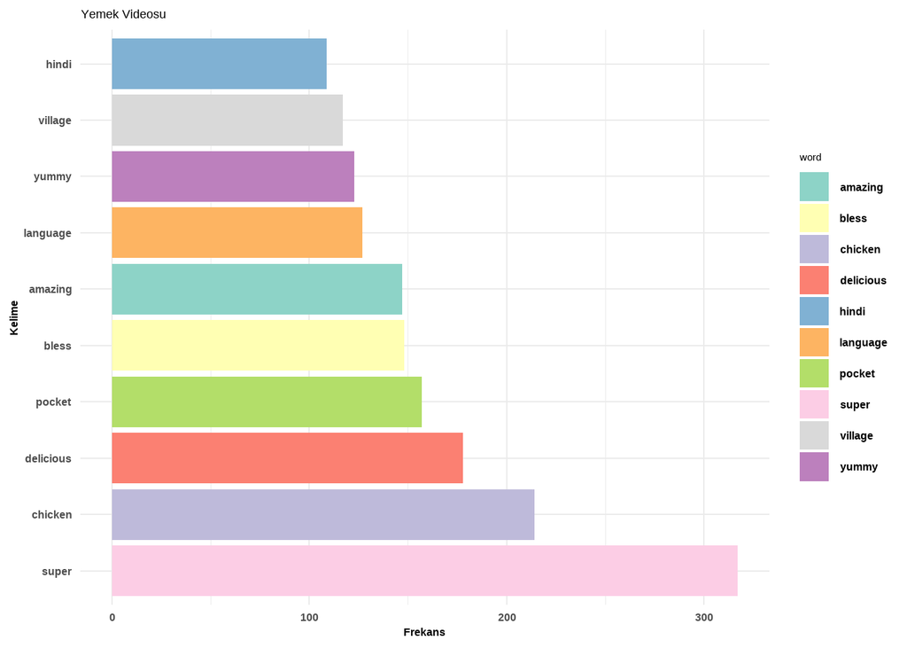

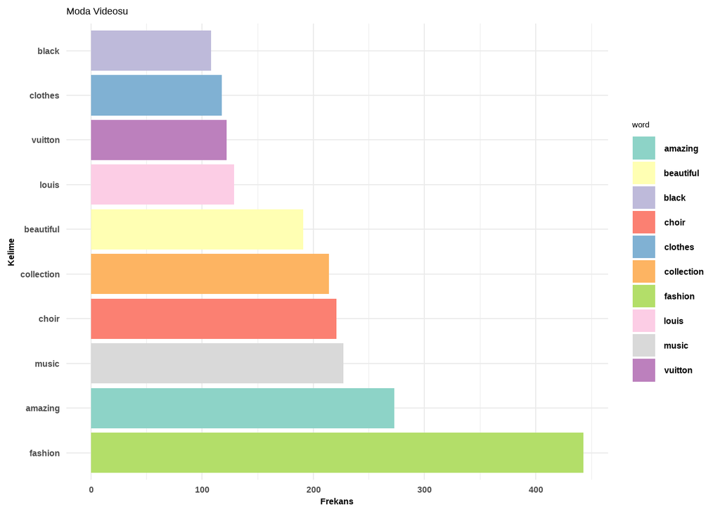

[5 more figures not shown]

```r
for (i in seq_along(temizlenmis_veriler)) {
  analiz <- temizlenmis_veriler[[i]]
  frekans <- analiz %>%
    count(word, sort = TRUE) %>%
    filter(n > 1)  # Frekansı 1'den büyük olanları filtrele

  # En yüksek frekanslı kelimeleri al
  top_words <- head(frekans, 10)

  # Grafik için tablonun başlığını oluştur
  tablo_baslik <- names(temizlenmis_veriler)[i]

  frekans_grafik <- ggplot(top_words, aes(x = reorder(word, -n), y = n, fill = word)) +
    geom_bar(stat = "identity") + # fill estetiği burada belirtildi
    scale_fill_brewer(palette = "Set3") +
    labs(x = "Kelime", y = "Frekans", title = tablo_baslik, size= 12) +
    theme_minimal() +
    coord_flip() +
     theme(axis.text.y = element_text(size = 12), # Y ekseni metin boyutu
          axis.title = element_text(size = 12, face = "bold", vjust = -0.2), # Eksen başlığı metin boyutu ve kalınlığı
          axis.text = element_text(size = 12, face = "bold"), # Eksen metin boyutu ve kalınlığı
          legend.text = element_text(size = 12, face = "bold")) # Lejant metin boyutu ve kalınlığı
  print(frekans_grafik)
}
```

## 6.Duygu Analizi

Frekanslarını bulduğumuz veriler için 8 duygu durumu olan bir duygu analizi yapalım. Bunu **NRC** leksikonu ile yapacağız.

### 6.1. Duygu Analizi Tablolaştırma

Yaptığımız duygu analizini tablolaştıralım.dplyr, ggplot2, tidytext, stringr, magrittr paketlerini kullanıyoruz.

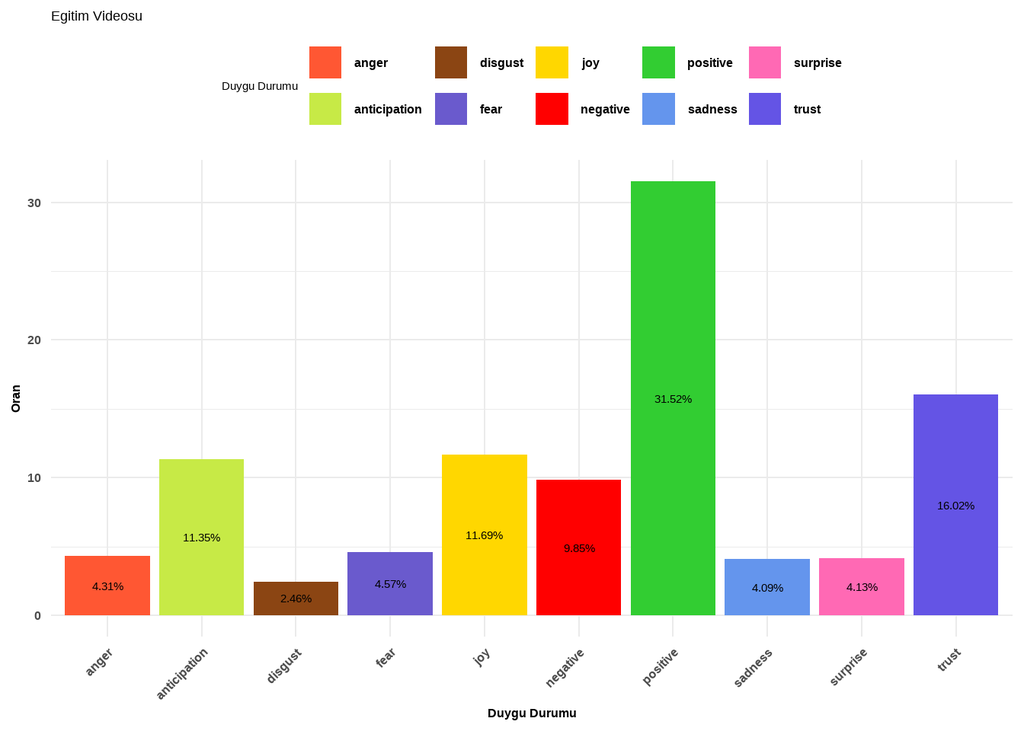

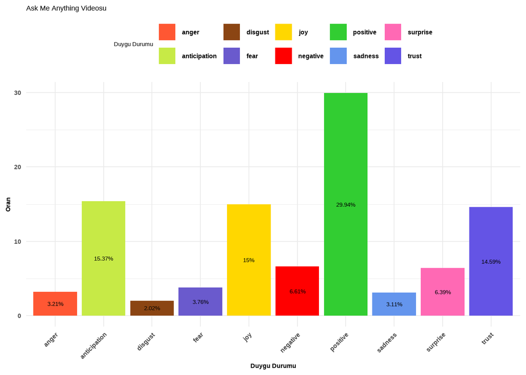

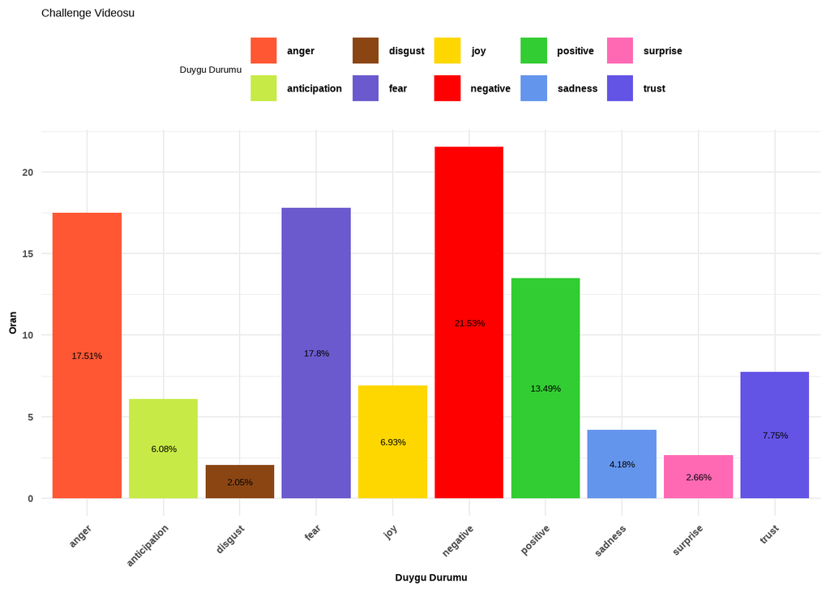

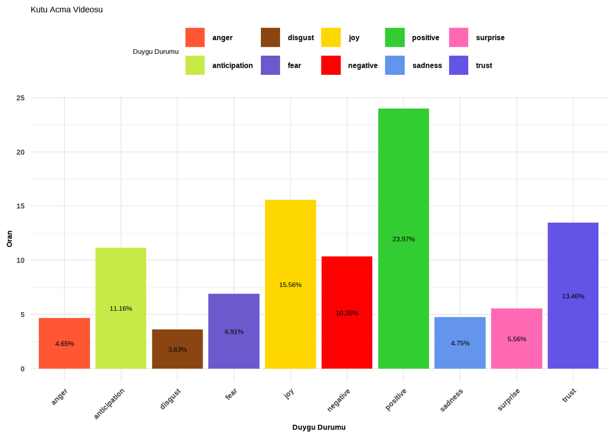

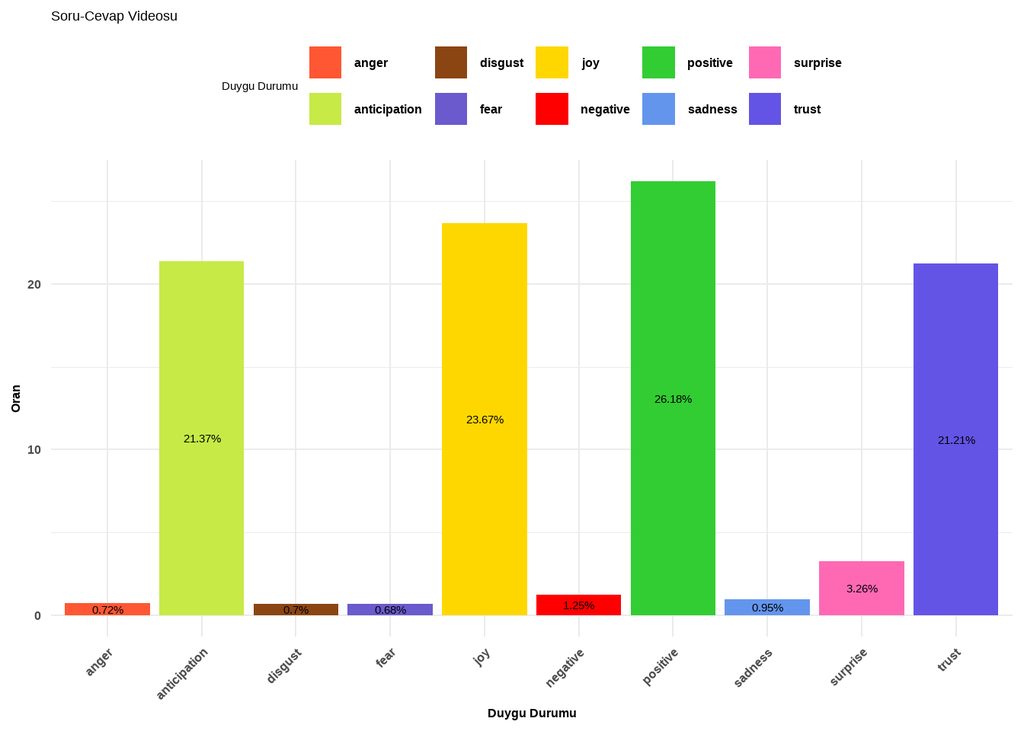

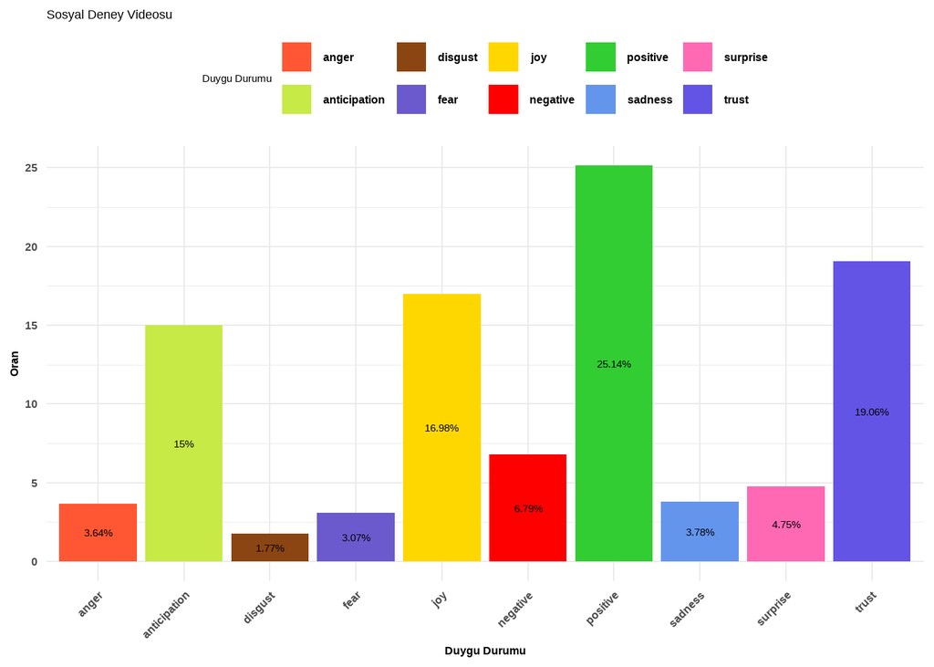

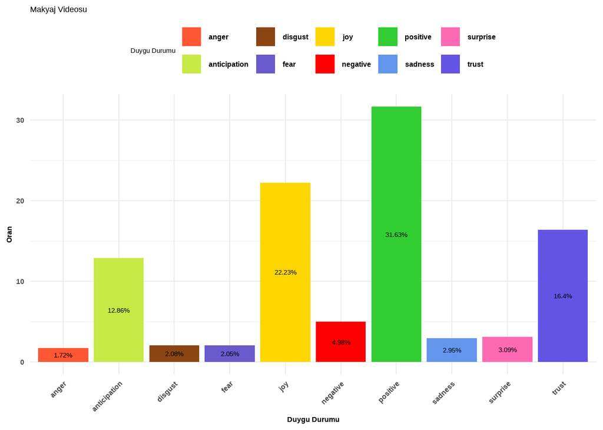

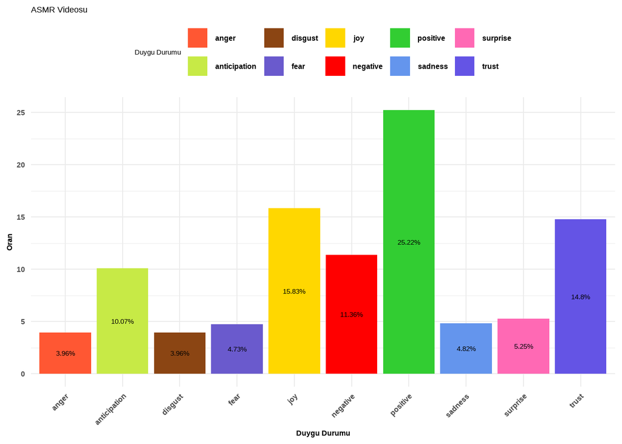

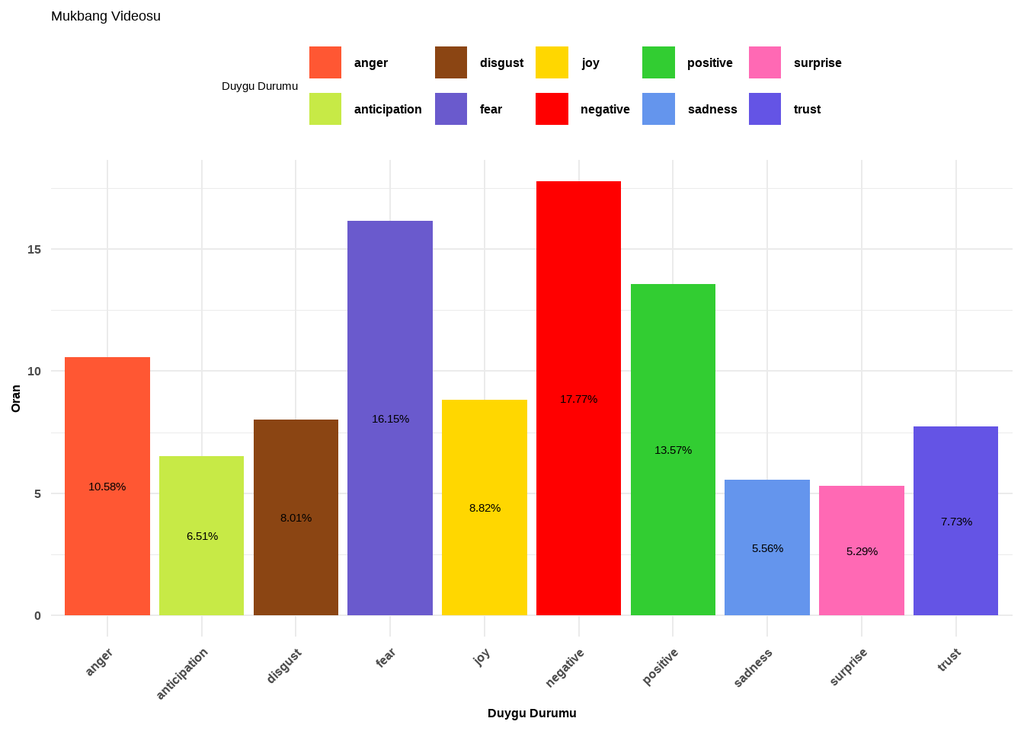

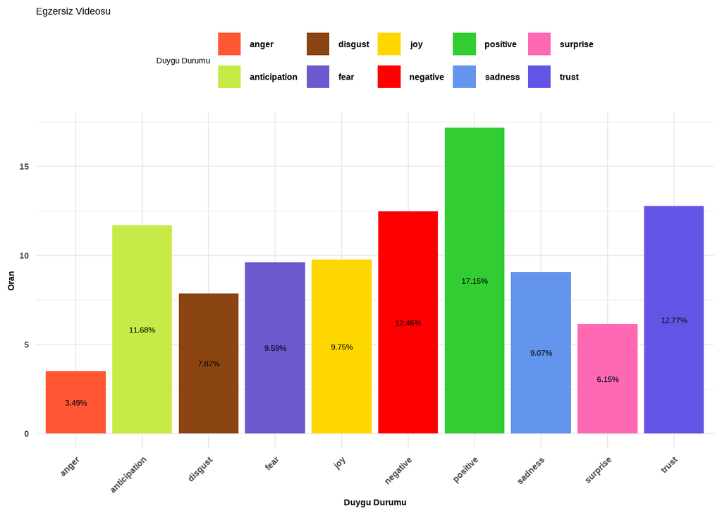

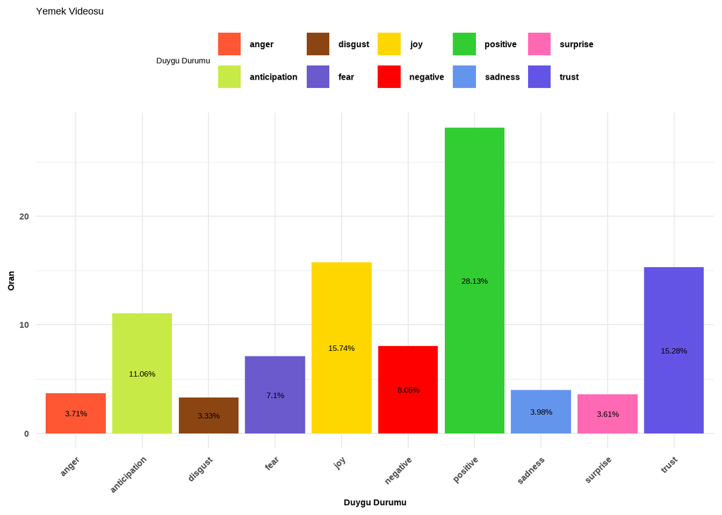

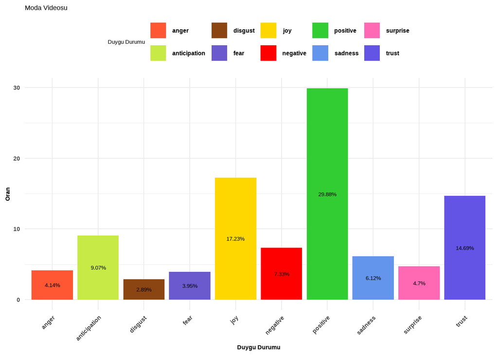

[5 more figures not shown]

```r
analyze_sentiment <- function(temizlenmis_veriler) {
  # Veriyi NRC duygu sözlüğü ile birleştirme
  polarized_data <- temizlenmis_veriler %>%
    inner_join(get_sentiments("nrc"), by = "word")

  # Duygu toplamlarını hesaplama
  duygu_toplamlari <- polarized_data %>%
    group_by(sentiment) %>%
    summarise(toplam=n()) %>%
    mutate(oran=round(toplam/sum(toplam)*100,2)) %>%
    arrange(desc(oran)) %>%
    rename("duygu"="sentiment")

  return(duygu_toplamlari)
}

# Her veri kümesi için duygu analizi yapma ve görselleştirme
for (i in seq_along(temizlenmis_veriler)) {
  duygu <- temizlenmis_veriler[[i]]

  # Duygu analizi yapma
  duygu_analizi <- analyze_sentiment(duygu)

  tablo_baslik <- names(temizlenmis_veriler)[i]

  # Grafik oluşturma ve çıktıya dönüştürme
  print(ggplot(duygu_analizi, aes(x = duygu, y = oran, fill = duygu)) +
    geom_col() +
    geom_text(aes(label = paste0(oran, "%")), position = position_stack(vjust = 0.5), color = "black", size = 4) +
    labs(title = tablo_baslik, x = "Duygu Durumu", y = "Oran") +
    scale_fill_manual(values = c("anger" = "#FF5733", "anticipation" = "#C7EA46", "trust" = "#6454E5",
                                  "joy" = "#FFD700", "fear" = "#6A5ACD", "sadness" = "#6495ED",
                                  "surprise" = "#FF69B4", "disgust" = "#8B4513", "positive" = "#32CD32",
                                  "negative" = "#FF0000"),
                      guide = guide_legend(title = "Duygu Durumu")) +
    theme_minimal() +
    theme(axis.text.x = element_text(angle = 45, hjust = 1)) +
    theme(legend.position = "top") +
      theme(axis.text.y = element_text(size = 12), # Y ekseni metin boyutu
          axis.title = element_text(size = 12, face = "bold", vjust = -0.2), # Eksen başlığı metin boyutu ve kalınlığı
          axis.text = element_text(size = 12, face = "bold"), # Eksen metin boyutu ve kalınlığı
          legend.text = element_text(size = 12, face = "bold")) # Lejant metin boyutu ve kalınlığı

  )
}
```

## 6.2. Pozitiflik Oranları

Her videonun pozitif duygularını alarak karşılaştıracağımız bir tablo oluşturalım.dplyr, ggplot2, tidytext, stringr, magrittr paketlerini kullanıyoruz.

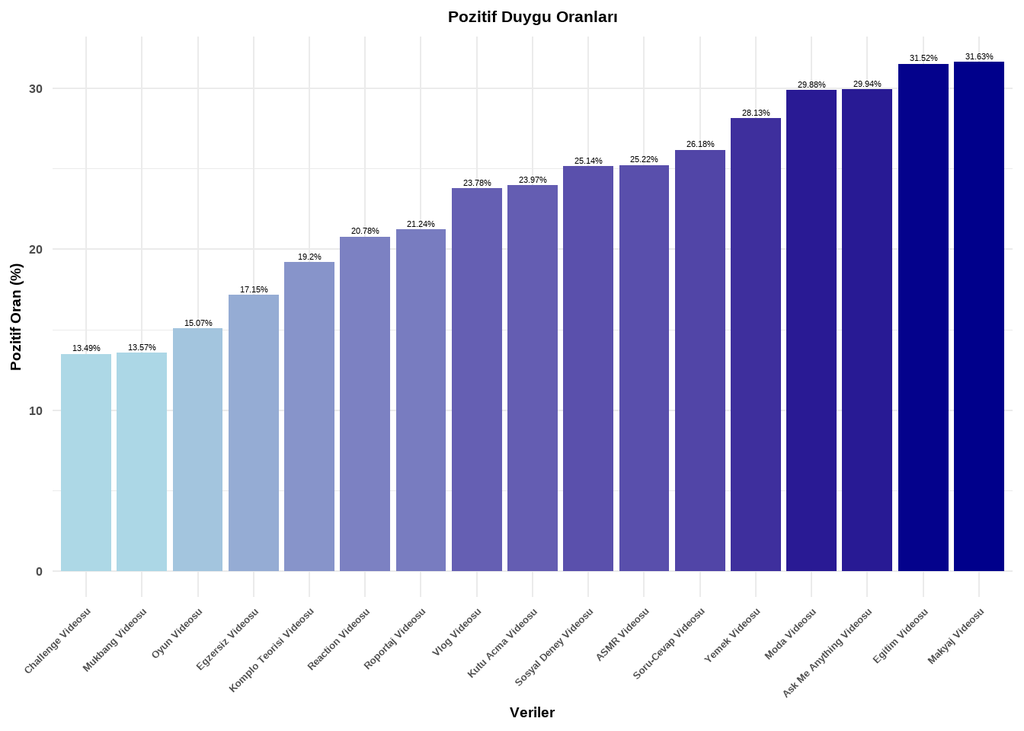

```r
# Pozitif duygu oranlarını hesaplayan bir fonksiyon
pozitif_duygular <- function(sentiment_totals) {
  positive_ratio <- sentiment_totals %>%
    filter(duygu == "positive") %>%
    pull(oran)

  if(length(positive_ratio) == 0) {
    positive_ratio <- 0
  }

  return(positive_ratio)
}

# Her veri kümesi için pozitif duygu oranlarını hesaplama
positive_ratios <- data.frame(Dosya = character(), Pozitif_Oran = numeric(), stringsAsFactors = FALSE)

for (i in seq_along(temizlenmis_veriler)) {
  analiz <- temizlenmis_veriler[[i]]

  # Duygu analizi yapma
  duygu_analizi <- analyze_sentiment(analiz)

  # Pozitif duygu oranını hesaplama
  pozitif_oran <- pozitif_duygular(duygu_analizi)

  # Dosya adı
  dosya_adi <- names(temizlenmis_veriler)[i]

  # Veri çerçevesine ekleme
  positive_ratios <- rbind(positive_ratios, data.frame(Dosya = dosya_adi, Pozitif_Oran = pozitif_oran))
}

# Pozitif oranlar tablosunu görselleştirme
ggplot(positive_ratios, aes(x = reorder(Dosya, Pozitif_Oran), y = Pozitif_Oran, fill = Pozitif_Oran)) +
  geom_col() +
  geom_text(aes(label = paste0(Pozitif_Oran, "%")), vjust = -0.5, color = "black", size = 3) +
  labs(title = "Pozitif Duygu Oranları", x = "Veriler", y = "Pozitif Oran (%)") +
  scale_fill_gradient(low = "lightblue", high = "darkblue") +
  theme_minimal() +
  theme(axis.text.x = element_text(angle = 45, hjust = 1, size = 10, face = "bold"),
        axis.text.y = element_text(size = 12, face = "bold"),
        axis.title = element_text(size = 14, face = "bold"),
        plot.title = element_text(size = 16, face = "bold", hjust = 0.5),
        legend.position = "none")
```

6.3. Negatiflik Oranları

Her videonun negatif duygularını alarak karşılaştıracağımız bir tablo hazırlayalım.

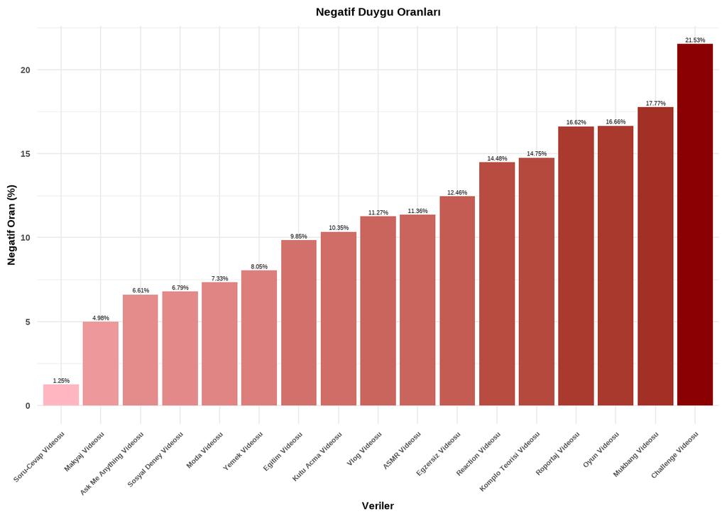

```r
library(ggplot2)
library(dplyr)

# Negatif duygu oranlarını hesaplayan bir fonksiyon
negatif_duygular <- function(sentiment_totals) {
  negative_ratio <- sentiment_totals %>%
    filter(duygu == "negative") %>%
    pull(oran)

  if(length(negative_ratio) == 0) {
    negative_ratio <- 0
  }

  return(negative_ratio)
}

# Her veri kümesi için negatif duygu oranlarını hesaplama
negative_ratios <- data.frame(Dosya = character(), Negatif_Oran = numeric(), stringsAsFactors = FALSE)

for (i in seq_along(temizlenmis_veriler)) {
  df <- temizlenmis_veriler[[i]]

  # Duygu analizi yapma
  duygu_analizi <- analyze_sentiment(df)

  # Negatif duygu oranını hesaplama
  negatif_oran <- negatif_duygular(duygu_analizi)

  # Dosya adı
  dosya_adi <- names(temizlenmis_veriler)[i]

  # Veri çerçevesine ekleme
  negative_ratios <- rbind(negative_ratios, data.frame(Dosya = dosya_adi, Negatif_Oran = negatif_oran))
}

# Negatif oranlar tablosunu görselleştirme
ggplot(negative_ratios, aes(x = reorder(Dosya, Negatif_Oran), y = Negatif_Oran, fill = Negatif_Oran)) +
  geom_col() +
  geom_text(aes(label = paste0(Negatif_Oran, "%")), vjust = -0.5, color = "black", size = 3) +
  labs(title = "Negatif Duygu Oranları", x = "Veriler", y = "Negatif Oran (%)") +
  scale_fill_gradient(low = "lightpink", high = "darkred") +
  theme_minimal() +
  theme(axis.text.x = element_text(angle = 45, hjust = 1, size = 10, face = "bold"),
        axis.text.y = element_text(size = 12, face = "bold"),
        axis.title = element_text(size = 14, face = "bold"),
        plot.title = element_text(size = 16, face = "bold", hjust = 0.5),
        legend.position = "none")
```

## 7.Emoji Analizi

Bu kısımda videoların altına gelen yorumlardaki emojileri analiz edeceğiz.

```r
analyze_emoji <- function(dataset) {
  emoji_tablosu <- table(unlist(dataset$emoji))
  emojiler <- data.frame(
    Emoji = names(emoji_tablosu),
    Tekrar_Sayisi = as.numeric(emoji_tablosu)
  ) %>%
    arrange(desc(Tekrar_Sayisi)) %>%
    slice_head(n = 30)

  return(emojiler)
}
```

### 7.1. Emoji Analizi Tablolaştırma

Yaptığımız emoji analizini emoji bulutu ile görselleştirelim. wordcloud2 , htmlwidgets paketlerini kullanıyoruz.

```r
for (i in seq_along(temizlenmis_veriler)) {
  dataset <- temizlenmis_veriler[[i]]

  # Emoji Analizi Yapma
  emojiler <- analyze_emoji(dataset)


  # Wordcloud Oluşturma
  emoji_wordcloud <- wordcloud2(emojiler, color = "white",backgroundColor = "black", size = 1.5)
}
print(emoji_wordcloud)
```

[output not shown]

Görselleştirdiğim emoji bulutunu aşağıdaki kod ile bilgisayara kaydediyorum.

htmlwidgets::saveWidget(widget = emoji_wordcloud, file = paste0(names(temizlenmis_veriler)[i], “_emoji_wordcloud.html”), selfcontained = TRUE)